# Nice Ride Capstone Project Statistical Report

Tony Tushar Jr

February 09, 2018

# Purpose of Report

This Exploratory Data Analysis (EDA) serves as a starting point for understanding the Nice Ride MN 2016-2017 dataset previously created and documented [here](https://github.com/tonytusharjr/Nice-Ride-MN-2017/blob/master/Nice%20Ride%20Data%201617.Rmd).

**Two main questions for this report and ultimate purpose of this capstone project:**

*Main Questions:*

- What are the effects of weather on bikeshare volume?
- How do weather effects on bikeshare volume differ between member and casual account types?

*Purpose of Capstone Project:*

- To provide a predictive model for 2018 weekly bikeshare volume based on the input of weather forecast variables and analysis of prior bikeshare seasons.

In this EDA we will perform the following steps:

**1. General exploration of dataset:**

- What is the distribution of trips per month, by year?
- What is the distribution of trips per day of the week, by account type?
- What is the distibution of trips by weekday and weekend for the season, by year, by account type?
- Summary of trip distance in miles
- Summary of trip duration in minutes

**2. Pearson’s product-moment correlations for the effects of primary weather variables on bikeshare volume:**

- Effect of average temperature
- Effect of average wind speed
- Effect of precipitation
- Effect of relative humidity
- Effect of heat index

**3. Welch Two Sample t-tests for measuring variances in average general biking characteristics and primary weather variables for member and casual bike account types:**

- Trip duration
- Trip distance
- Temperature
- Relative Humidity
- Heat index

**4. Conclusion: Brief summary of findings, mention of further possible exploration, and next steps in predictive modeling process**

## Caveats

*Through this analysis outliers were uncovered for roughly 1500 observations for the trip duration variables. They represent less than one percent of the total observations and were removed prior conducting statistical tests.*

# Load dataset, set ggplot theme, run multi plot function, and preview variables

```r
head(Rides1617)
```

| Start_DoWeek | Weekend | Start_Year | Start_Month | Start_Day | Start_Station | Start_Latitude | Start_Longitude | Start_Docks | End_Year | End_Month | End_Day | End_Station | End_Latitude | End_Longitude | End_Docks | Total_Duration_Seconds | Total_DurationMin | Trip_DistanceMiles | Account_Type | Avg_Temp | Avg_Wind | Precip | Snow | Rel_Humidity | Fog | Heavy_Fog | Thunder | Hail | Haze |
| --- | --- | --- | --- | --- | --- | --- | --- | --- | --- | --- | --- | --- | --- | --- | --- | --- | --- | --- | --- | --- | --- | --- | --- | --- | --- | --- | --- | --- | --- |
| Mon | 0 | 2016 | 4 | 4 | 4th Street & 17th Ave SE | 44.97913 | -93.23189 | 15 | 2016 | 4 | 4 | Washington & Marquette | 44.98087 | -93.26693 | 19 | 581 | 9.683333 | 4.450760 | Casual | 34 | 7.83 | 0 | 0 | 54 | 0 | 0 | 0 | 0 | 0 |
| Mon | 0 | 2016 | 4 | 4 | Washington & Cedar | 44.97344 | -93.24748 | 20 | 2016 | 4 | 4 | Como Ave SE & 29th Ave SE | 44.98793 | -93.21289 | 15 | 1032 | 17.200000 | 5.094476 | Member | 34 | 7.83 | 0 | 0 | 54 | 0 | 0 | 0 | 0 | 0 |
| Mon | 0 | 2016 | 4 | 4 | Sanford Hall | 44.98083 | -93.24028 | 23 | 2016 | 4 | 4 | Washington Ave SE & Union Street SE | 44.97394 | -93.23210 | 27 | 392 | 6.533333 | 1.612214 | Casual | 34 | 7.83 | 0 | 0 | 54 | 0 | 0 | 0 | 0 | 0 |
| Mon | 0 | 2016 | 4 | 4 | Social Sciences | 44.97136 | -93.24375 | 29 | 2016 | 4 | 4 | Sanford Hall | 44.98083 | -93.24028 | 23 | 293 | 4.883333 | 1.753044 | Member | 34 | 7.83 | 0 | 0 | 54 | 0 | 0 | 0 | 0 | 0 |
| Mon | 0 | 2016 | 4 | 4 | S 8th Street & 2nd Ave S | 44.97480 | -93.27065 | 19 | 2016 | 4 | 4 | 28th Street & Nicollet Ave. S | 44.95190 | -93.27831 | 15 | 1057 | 17.616667 | 4.215069 | Member | 34 | 7.83 | 0 | 0 | 54 | 0 | 0 | 0 | 0 | 0 |
| Mon | 0 | 2016 | 4 | 4 | Loring Park | 44.97150 | -93.28493 | 15 | 2016 | 4 | 4 | Logan Park | 44.99882 | -93.25276 | 15 | 1931 | 32.183333 | 6.369359 | Casual | 34 | 7.83 | 0 | 0 | 54 | 0 | 0 | 0 | 0 | 0 |

# 1. General exploration of dataset:

## Distribution of trips by month, for 2016-2017 seasons

| Start_Year | Start_Month | n | Percent_Year |
| --- | --- | --- | --- |
| 2016 | 4 | 33447 | 0.03745498 |
| 2016 | 5 | 62985 | 0.07053255 |
| 2016 | 6 | 71716 | 0.08030979 |
| 2016 | 7 | 84324 | 0.09442862 |
| 2016 | 8 | 69542 | 0.07787528 |
| 2016 | 9 | 57301 | 0.06416743 |

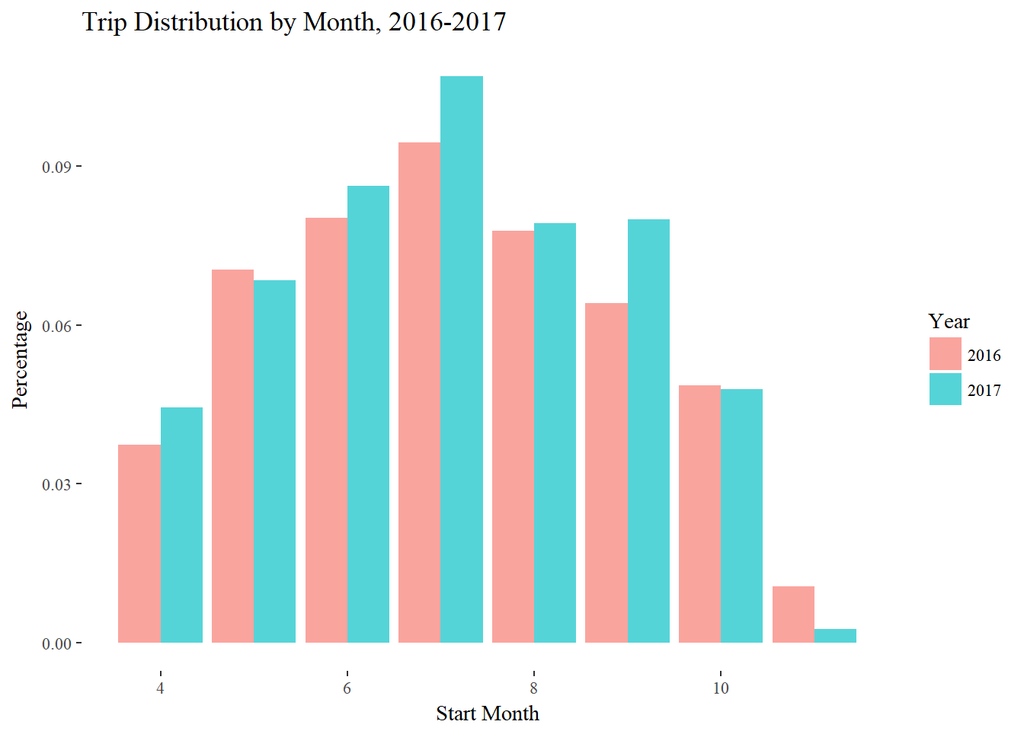

> Trip distrubution shows greatest variance year-over-year during the summer months. It is possible road construction played a larger role in 2016 than 2017, impacting ride volume negatively. However, it is difficult to control for road construction from one year to the next, this is simply a hypothesis to note but not investigate in the scope of this project.

## Distribution of trips per day of the week, by account type

| Start_Year | Start_DoWeek | Account_Type | n | Percent_Year |
| --- | --- | --- | --- | --- |
| 2016 | Sun | Casual | 37048 | 0.04148749 |
| 2016 | Sun | Member | 32820 | 0.03675285 |
| 2016 | Mon | Casual | 17486 | 0.01958136 |
| 2016 | Mon | Member | 42558 | 0.04765776 |
| 2016 | Tue | Casual | 12422 | 0.01391054 |
| 2016 | Tue | Member | 43336 | 0.04852899 |

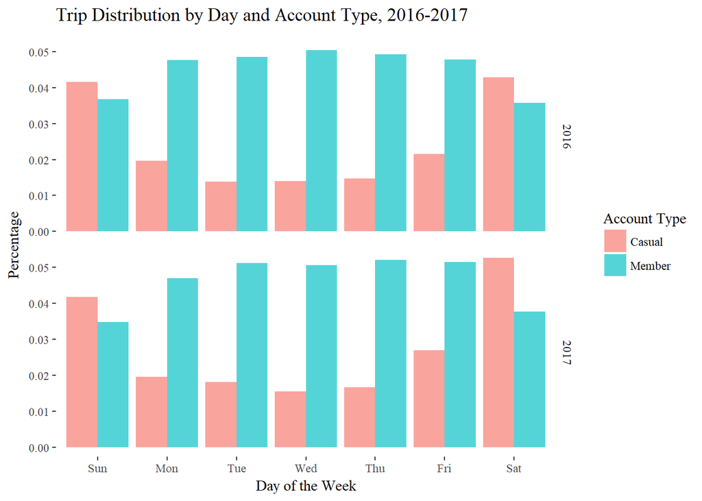

> Daily distribution by year confirms consistency year-over-year, member riders are utilizing bikshare for commuting purposes while casual riders utilize bikeshare for leisure, inverse of one another. An hourly breakdown of bike volume would further detail this observation, however, this is not relevant to the greater scope of our project purpose.

## Distibution of trips per year by account type

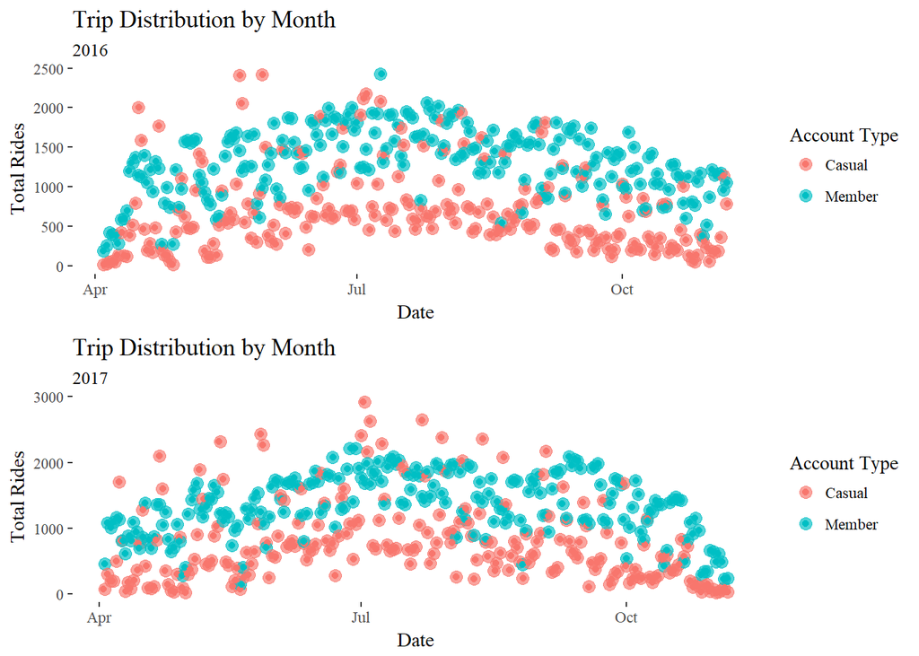

> Member rides dominant casual year-over-year. Both bike seasons demonstrate a convex shape visually, ride volume peaks in the summer months. It is worth noting that 2017 demonstrates more frequent peak volume points for casual riders above members, perhaps these max points are related to holidays or city-wide events?

## Summary of trip distance

```
##    Min. 1st Qu.  Median    Mean 3rd Qu.    Max.
##   0.000   1.047   1.944   2.523   3.324  29.046
```

> Median trip distance is 1.944 miles while the max is 29 miles, is this logical in comparison to trip duration?

## Summary of trip duration in minutes

```
##      Min.   1st Qu.    Median      Mean   3rd Qu.      Max.
##      1.00      6.80     12.72     34.81     24.50 280043.68
```

> It is odd to see a max ride observation of over 280,000 minutes, this equates to 194 days! How many bike rides are greater than one day? This is the process by which we can determine outliers as previously mentioned.

```r
# What percentage of bike rides are over one day in length?
# Trips equal to or less than one day
Rides_Day <- Rides1617 %>% mutate(Total_DurationDay = (Total_DurationMin <= 24*60))

Day_Length <- nrow(Rides_Day)

sum(Rides_Day$Total_DurationDay/Day_Length)
```

```
## [1] 0.9983225
```

## Remove outliers from dataset

> Now that we are working with a modified dataset absent of outliers, we should also consider adding a heat index variable to this dataset, as heat index more accurately captures the “feel temperature” of a given observation.

# 2. Correlation testing for the effects of primary weather variables on bikeshare volume:

## Effect of average temperature

```
##
##  Pearson's product-moment correlation
##
## data:  Temp$Avg_Temp and Temp$n
## t = 15.861, df = 866, p-value < 2.2e-16
## alternative hypothesis: true correlation is not equal to 0
## 95 percent confidence interval:
##  0.4212174 0.5244458
## sample estimates:
##       cor
## 0.4744612
```

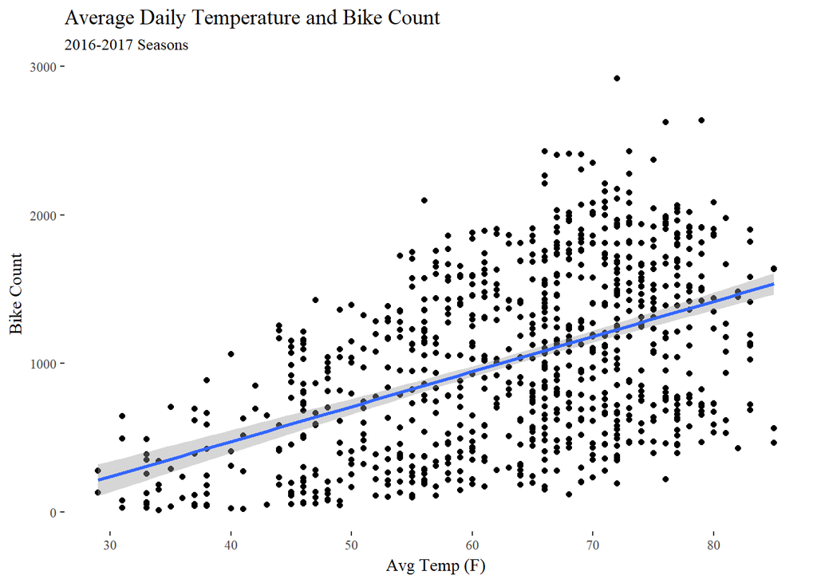

> Null hypothesis: there is no correlation between average daily temperature and bike volume. We reject the null hypothesis based on the statistical significance of a p value less than 0.05 and a correlation coefficient of 0.47.

## Effect of average wind speed

```
##
##  Pearson's product-moment correlation
##
## data:  Wind$Avg_Wind and Wind$n
## t = -6.3699, df = 866, p-value = 3.067e-10
## alternative hypothesis: true correlation is not equal to 0
## 95 percent confidence interval:
##  -0.2742415 -0.1470882
## sample estimates:
##        cor
## -0.2115599
```

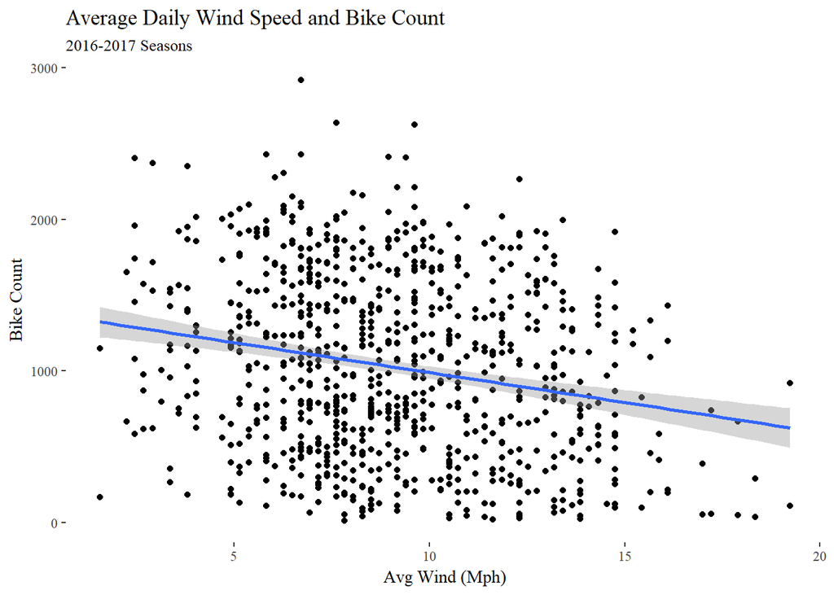

> Null hypothesis: there is no correlation of average daily wind to daily bike count. We reject the null hypothesis based on the statistical significance of a p value less than 0.05 and a correlation coefficient of -0.21.

## Effect of precipitation

```
##
##  Pearson's product-moment correlation
##
## data:  Precip$Precip and Precip$n
## t = -5.9179, df = 866, p-value = 4.695e-09
## alternative hypothesis: true correlation is not equal to 0
## 95 percent confidence interval:
##  -0.2602785 -0.1323447
## sample estimates:
##        cor
## -0.1971508
```

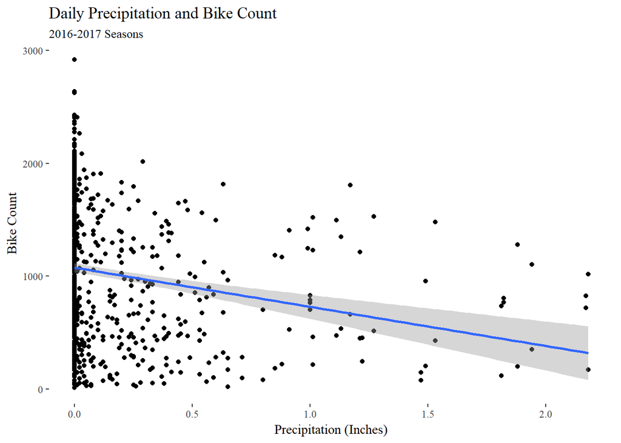

> Null hypothesis: There is no correlation between precipitation and bike volume. We reject the null hypothesis based on the statistical significance of a p value less than 0.05 and an inverse correlation coefficient of -0.20.

## Effect of relative humidity

```
##
##  Pearson's product-moment correlation
##
## data:  Humidity$Rel_Humidity and Humidity$n
## t = -8.5128, df = 816, p-value < 2.2e-16
## alternative hypothesis: true correlation is not equal to 0
## 95 percent confidence interval:
##  -0.3473439 -0.2213840
## sample estimates:
##        cor
## -0.2855969
```

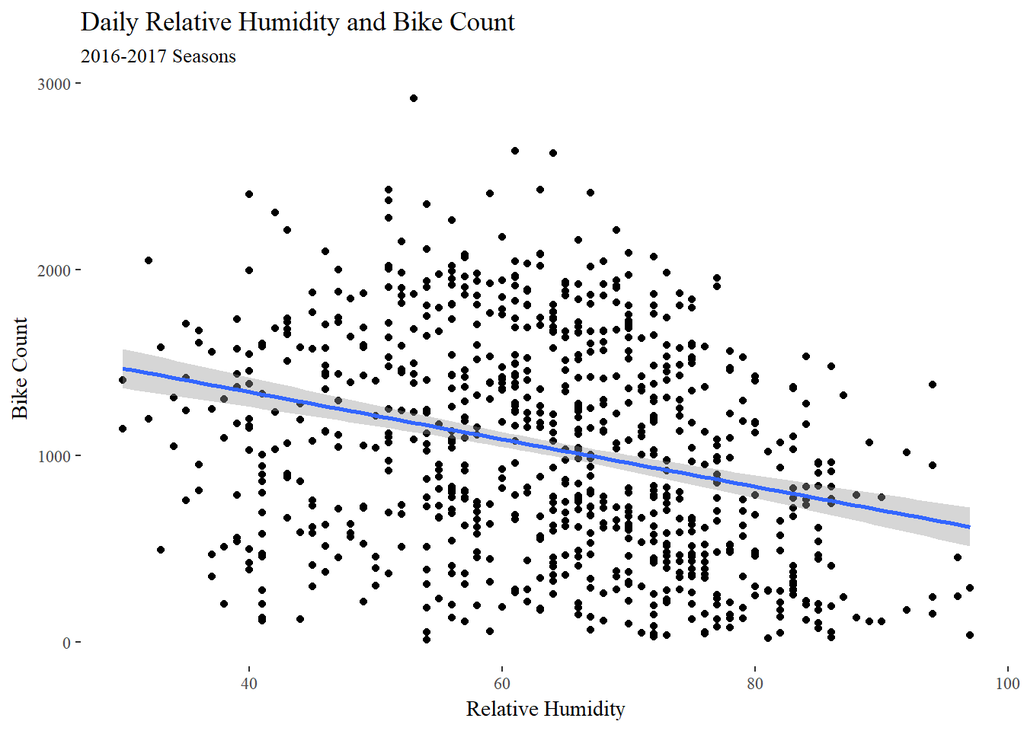

> Null hypothesis: There is no correlation between relative humidity and bike volume. We reject the null hypothesis based on the statistical significance of a p value less than 0.05 and an inverse correlation coefficient of -0.29.

## Effect of heat index

```
##
##  Pearson's product-moment correlation
##
## data:  Heat_Index$Heat_Index and Heat_Index$n
## t = 13.636, df = 816, p-value < 2.2e-16
## alternative hypothesis: true correlation is not equal to 0
## 95 percent confidence interval:
##  0.3732655 0.4850148
## sample estimates:
##       cor
## 0.4307901
```

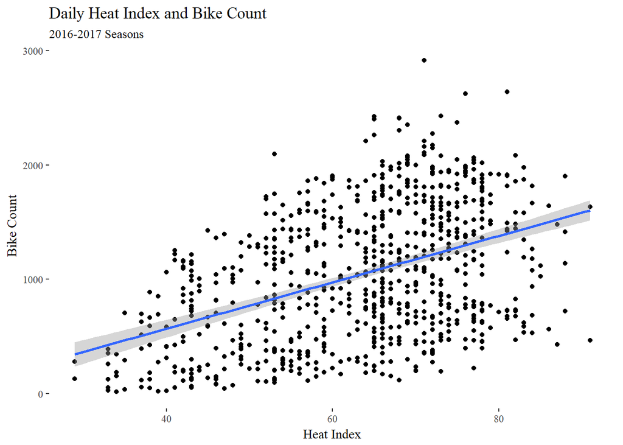

> Null hypothesis: There is no correlation between heat index and bike volume. We reject the null hypothesis based on the statistical significance of a p value less than 0.05 and a correlation coefficient of 0.43.

# 3. Welch Two Sample t-tests for measuring variances in average general biking characteristics and primary weather variables for member and casual bike account types:

## Trip duration

```r
t.test(data=Account_Tests, Total_DurationMin~Account_Type)
```

```
##
##  Welch Two Sample t-test
##
## data:  Total_DurationMin by Account_Type
## t = 155.89, df = 362350, p-value < 2.2e-16
## alternative hypothesis: true difference in means is not equal to 0
## 95 percent confidence interval:
##  22.78977 23.37012
## sample estimates:
## mean in group Casual mean in group Member
##             37.31497             14.23503
```

> Null hypothesis (H0): There is no difference in the mean trip duration of member and casual account types. Alternative hypothesis (H1): There is a difference in the mean trip duration of member and casual account types. In this case, we reject the null hypothesis as the probability of there being no difference in mean trip duration for account types is very, very small. *On average, casual bike riders favor bike trips longer than members.*

## Trip distance

```r
t.test(data=Account_Tests, Trip_DistanceMiles~Account_Type)
```

```
##
##  Welch Two Sample t-test
##
## data:  Trip_DistanceMiles by Account_Type
## t = 3.5525, df = 578700, p-value = 0.0003817
## alternative hypothesis: true difference in means is not equal to 0
## 95 percent confidence interval:
##  0.008584695 0.029715775
## sample estimates:
## mean in group Casual mean in group Member
##             2.532404             2.513254
```

> Null hypothesis (H0): There is no difference in the mean trip distance of member and casual account types. Alternative hypothesis (H1): There is a difference in the mean trip distance of member and casual account types. In this case, we reject the null hypothesis as the probability of there being no difference in mean trip distance for account types is very, very small. *On average, casual bike riders favor a slightly longer riding distance.*

## Temperature

```r
t.test(data=Account_Tests, Avg_Temp~Account_Type)
```

```
##
##  Welch Two Sample t-test
##
## data:  Avg_Temp by Account_Type
## t = 87.543, df = 747400, p-value < 2.2e-16
## alternative hypothesis: true difference in means is not equal to 0
## 95 percent confidence interval:
##  1.777764 1.859190
## sample estimates:
## mean in group Casual mean in group Member
##             67.82874             66.01027
```

> Null hypothesis (H0): There is no difference in the mean temperature of member and casual account types. Alternative hypothesis (H1): There is a difference in the mean temperatures of member and casual account types. In this case, we reject the null hypothesis as the probability of there being no difference in mean temperature for account types is very, very small. *On average, casual bike riders favor a slightly warmer average temperature than member riders.*

## Wind Speed

```r
t.test(data=Account_Tests, Avg_Wind~Account_Type)
```

```
##
##  Welch Two Sample t-test
##
## data:  Avg_Wind by Account_Type
## t = -29.747, df = 664330, p-value < 2.2e-16
## alternative hypothesis: true difference in means is not equal to 0
## 95 percent confidence interval:
##  -0.2109829 -0.1848990
## sample estimates:
## mean in group Casual mean in group Member
##             8.553975             8.751916
```

> Null hypothesis (H0): There is no difference in the mean wind speed of member and casual account types. Alternative hypothesis (H1): There is a difference in the mean wind speed of member and casual account types. In this case, we reject the null hypothesis as the probability of there being no difference in mean riding distance for account types is very, very small. *On average, casual bike riders favor a slightly lower wind speed for riding compared to member riders.*

## Precipitation

```r
t.test(data=Account_Tests, Precip~Account_Type)
```

```
##
##  Welch Two Sample t-test
##
## data:  Precip by Account_Type
## t = -49.317, df = 747490, p-value < 2.2e-16
## alternative hypothesis: true difference in means is not equal to 0
## 95 percent confidence interval:
##  -0.03113073 -0.02875090
## sample estimates:
## mean in group Casual mean in group Member
##           0.08238605           0.11232687
```

> Null hypothesis (H0): There is no difference in the mean precipiation of member and casual account type rides. Alternative hypothesis (H1): There is a difference in the mean precipiation of member and casual account type rides. In this case, we reject the null hypothesis as the probability of there being no difference in mean precipitation for account types is very, very small. *On average, casual bike riders favor less precipitation while riding compared to member riders.*

## Relative humidity

```r
t.test(data=Account_Tests, Rel_Humidity~Account_Type)
```

```
##
##  Welch Two Sample t-test
##
## data:  Rel_Humidity by Account_Type
## t = -86.829, df = 657360, p-value < 2.2e-16
## alternative hypothesis: true difference in means is not equal to 0
## 95 percent confidence interval:
##  -2.433958 -2.326502
## sample estimates:
## mean in group Casual mean in group Member
##             60.05355             62.43378
```

> Null hypothesis (H0): There is no difference in the mean relative humidity of member and casual account type rides. Alternative hypothesis (H1): There is a difference in the mean relative humidity of member and casual account type rides. In this case, we reject the null hypothesis as the probability of there being no difference in mean relative humidity for account types is very, very small. *On average, casual bike riders favor lower relative humidity while riding compared to member riders.*

## Heat index

```r
t.test(data=Account_Tests, Heat_Index~Account_Type)
```

```
##
##  Welch Two Sample t-test
##
## data:  Heat_Index by Account_Type
## t = 73.701, df = 707870, p-value < 2.2e-16
## alternative hypothesis: true difference in means is not equal to 0
## 95 percent confidence interval:
##  1.674314 1.765798
## sample estimates:
## mean in group Casual mean in group Member
##             67.47338             65.75333
```

> Null hypothesis (H0): There is no difference in the mean heat index of member and casual account type rides. Alternative hypothesis (H1): There is a difference in the mean heat index of member and casual account type rides. In this case, we reject the null hypothesis as the probability of there being no difference in mean heat index for account types is very, very small. *On average, casual bike riders favor a higher heat index for riding compared to member riders.*

# 4. Conclusion: Brief summary of findings, mention of possible further exploration, and next steps in predictive modeling process

## Brief summary of findings:

All t-tests resulted in rejecting the null hypothesis as there was little probabilty for a difference of zero between member and casual account type ride characteristics in relation to the average observations of trip distance, trip duration, and primary weather variables. Running t-tests to compare trip distance and duration between the two groups, we determined a high probabilty that casual rider trip duration is on average over twice as long as member trip duration. As for trip distance, we reject the null hypothesis that there is no difference in trip distance between account types. However this was our weakest p value for all t-tests conducted. While there is a difference in average trip distance by account type, the difference is minimal.

In comparison to casual riders, member riders appear more willing to handle average weather variables in the following manner:

- Lower temperatures
- Higher wind speed
- Higher precipitation
- Higher relative humidty
- Lower heat index

## Next steps in predictive modeling process:

1. Apply linear regression to the dataset
2. Determine supervised or unsupervised approach to the model
3. Determine which machine learning technique to use
4. Decide on evaluation metrics for determining quality of predictive model
5. consider ways to visualize the predictive model